# Análise Assintótica

Prof. Juliano Foleis

## Notação Assintótica

- Conseguimos mostrar que `Soma_TS` tem custo $T(n) = \alpha n^2 + \beta n + \gamma$.
- O nosso interesse real não é saber exatamente a função de custo, mas sim o **comportamento assintótico** dela.
- O comportamento assintótico refere-se a quanto o custo do algoritmo aumenta conforme $n$ cresce.
- Por exemplo, quando falamos do custo de `Soma_TS`, apenas nos referimos a ele por “custo quadrático”, uma vez que é o termo $\alpha n^2$ que define o comportamento da função!

## Notação Assintótica

- A notação assintótica é um formalismo matemático que nos permite comparar funções para $n$ grande.
- Podemos usar a notação assintótica para comparar custos de algoritmos diferentes para um mesmo problema, com o objetivo de escolher o algoritmo mais eficiente.
- Se um algoritmo **A** tem custo $\Theta(n)$ e o algoritmo **B** tem custo $\Theta(n^2)$, dizemos que o algoritmo **A** tem custo assintoticamente inferior que o algoritmo **B**. Note que podemos concluir isso mesmo sem conhecer exatamente as funções de custo de **A** ou **B**!

## Notação $O$

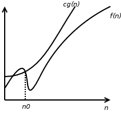

## Notação $O$

**Definição**

$O(g(n)) = \{ f(n): \text{existem constantes positivas } n_0 \text{ e } c \\ \text{ tal que } f(n) \leq cg(n), \forall n \, | \, n \geq n_0 \}$

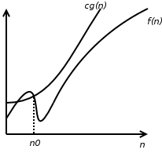

- $g(n)$ é um limite superior para $f(n)$
- A partir de um determinado $n_0$, $f(n)$ será sempre menor ou igual a $cg(n)$.
- Note que $O(g(n))$ é o conjunto de todas as funções limitadas superiormente por $g(n)$, ou seja, $f(n) \in O(g(n))$.

## Notação O – Exemplos

$$2n + 1 = O(n^2)$$

$$n^2 + 2n = O(n^2)$$

$$3n + 2 = O(n^3)$$

$$3\lg(n) = O(n)$$

$$4n \lg(n) = O(n^2)$$

$$n^3 + 20n + 1 \neq O(n^2)$$

## Notação $\Omega$ (ômega)

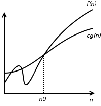

## Notação $\Omega$ (ômega)

**Definição**

$\Omega(g(n)) = \{ f(n): \text{existem constantes positivas } n_0 \text{ e } c \\ \text{ tal que } cg(n) \leq f(n), \forall n \, | \, n \geq n_0 \}$

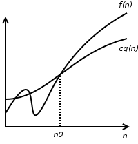

- $g(n)$ é um limite inferior para $f(n)$
- A partir de um determinado $n_0$, $cg(n)$ será sempre menor ou igual a $f(n)$.
- Note que $\Omega(g(n))$ é o conjunto de todas as funções limitadas inferiormente por $g(n)$, ou seja, $f(n) \in \Omega(g(n))$.

## Notação $\Omega$ – Exemplos

$$n^3+ 20n = \Omega(n^2)$$

$$3n + 4 = \Omega(n)$$

$$n^3 + 2n = \Omega(n)$$

$$10n = \Omega(\lg(n))$$

## Notação $\Theta$ (teta)

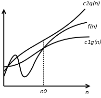

## Notação $\Theta$ (teta)

**Definição**

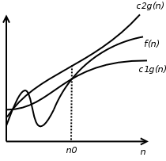

- $g(n)$ é um limite assintoticamente restrito para $f(n)$
- $f(n)$ tem o mesmo comportamento assintótico que $g(n)$
- Note que $\Theta(g(n))$ é o conjunto de todas as funções que são assitoticamente restritas a $g(n)$, ou seja, $f(n) \in \Theta(g(n))$.

## Notação $\Theta$ – Exemplos

$$n^3+ 20n = \Theta(n^3)$$

$$3n + 4 = \Theta(n)$$

$$n^2 + 3 = \Theta(n^2)$$

$$3\lg(n) = \Theta(\lg(n))$$

$$3n^2 \neq \Theta(n^3)$$

$$3n^2 \neq \Theta(n)$$

## Teoremas Importantes

**Teorema 1**

$\text{Para duas funções quaisquer } f(n) \text{ e } g(n) \text{,} \\ f(n) = \Theta(g(n)) \text{ se e somente se } f(n) = O(g(n)) \text{ E } f(n) = \Omega(g(n)).$

## Teoremas Importantes

**Teorema 2**

$$\text{Para qualquer polinômio } p(n) = \sum_{i}^{d} a_in^i
\text{ onde } a_i \text{ são constantes E } a_d > 0 \text{, }
\\
p(n) = \Theta(n^d).$$

Em outras palavras, um polinômio $p(n)$ de grau $d$ é $\Theta(n^d)$.

## Exemplos (Teorema 2)

$$2n^2 + 3n + 1 = \Theta(n^2)$$

$$5n^3 + 3n^2 + n = \Theta(n^3)$$

$$10 = \Theta(1)$$

## Teoremas Importantes

**Teorema 3**

$$\text{Para duas funções quaisquer } f(n) \text{ e } g(n) \text{, } \Theta(f(n) + g(n)) = \Theta(\max(f(n), g(n)))$$

**Intuição:** a função de maior custo assintótico domina o custo da função-soma.

## Exemplos (Teorema 3)

$$f(n) = n \land g(n) = n^2 \Rightarrow \Theta(f(n) + g(n)) = \Theta(n^2).$$

$$f(n) = \lg(n) \land g(n) = n \Rightarrow \Theta(f(n) + g(n)) = \Theta(n).$$

$$f(n) = n\lg(n) \land g(n) = n \Rightarrow \Theta(f(n) + g(n)) = \Theta(n \lg(n)).$$

## Teste do Limite

Sejam duas funções $f(n)$ e $g(n)$ positivas e monótonas crescentes. Para conhecer a relação assintótica entre $f(n)$ e $g(n)$, podemos usar o teste do limite.

$$\text{Seja } L = \lim_{n \rightarrow \infty} \frac{f(n)}{g(n)}$$

1. Se $L = 0$, então $f(n) = O(g(n))$.
2. Se $L = \infty$, então $f(n) = \Omega(g(n))$.
3. Se $L = C$, tal que $C$ é uma constante diferente de zero, então $f(n) = \Theta(g(n))$.

## Outras Propriedades

### Transitividade

Se $f(n) = \Theta(g(n))$ e $g(n) = \Theta(h(n))$ então $f(n) = \Theta(h(n))$

Se $f(n) = O(g(n))$ e $g(n) = O(h(n))$ então $f(n) = O(h(n))$

Se $f(n) = \Omega(g(n))$ e $g(n) = \Omega(h(n))$ então $f(n) = \Omega(h(n))$

## Outras Propriedades

### Propriedade Reflexiva

$f(n) = \Theta(f(n))$

$f(n) = O(f(n))$

$f(n) = \Omega(f(n))$

## Outras Propriedades

### Simetria

$f(n) = \Theta(g(n)) \Leftrightarrow g(n) = \Theta(f(n))$

### Simetria Transposta

$f(n) = O(g(n)) \Leftrightarrow g(n) = \Omega(f(n))$

### Intuição para Comparação

$f(n) = O(g(n))$ é análogo a $a \leq b$

$f(n) = \Omega(g(n))$ é análogo a $a \geq b$

$f(n) = \Theta(g(n))$ é análogo a $a = b$

## Bibliografia

[CRLS] CORMEN, T. H. et al. Algoritmos: Teoria e Prática. Elsevier, 2012. 3a Ed. Capítulo 3 (Crescimento de Funções), Seção 3.1